# Collate historical Baltic Sea trawl survey data

Author

Max Lindmark

Published

2025-03-05

This script reads code and data collated by Orio et al around 2017 for his PhD thesis on CPUE from various national surveys prior to DATRAS and the later gear homogenization (around 2010). The goal is to archive these data until 2016, and then append newer data from DATRAS which can be standardized in a much easier way (for *many* reasons).

I have here copied this code and put it in chunks more or less as is! I have trimmed it in places and added species. I have removed the pelagic species because I won’t use the catch information, and there is no biological information (“CA”) that is not on DATRAS (historical Swedish and Latvian data is focused on cod and flounder).

The script saves CA data for cod and flounder but not the other species because if I need those I’ll take them directly from DATRAS (no historical data for those).

I have also kept the original folder structure. The original script is “standardization_database.R”, which is available on the SLU server together with data (and in this repo). We have communicated with the Latvians (April 15th 2024) and have approval to re-use the data (even if we strictly do not need the approval…).

This first chunk reads in Swedish historical data and data from Fiskdata2 (internal database). It returns an object called DataStuart, with standardized CPUE in numbers (CPUEst).

```r
library(tidyr)
library(dplyr)
library(purrr)
library(ggplot2)
library(maptools)
library(lubridate)
# install.packages("maptools", repos = "https:/packagemanager.posit.co/cran/2023-10-13")
# install.packages('DATRAS',repos='http:/www.rforge.net/',type='source')
library(DATRAS)
library(doBy)
library(raster)
library(forcats)
library(readr)
library(tidylog)
```

## Swedish historical data and FD2

```r
####### standardization of trawl survey database

# From Alessandro Orios PhD work
# Updated and adapted by Max 2024.05.15.
# Minimal changes to script, just updates to make it run

####### Swedish historical data
####### load historical data

home <- here::here()

stand <- read.csv(paste0(home, "/data/trawl-data-historical/Raw.csv"), sep = ";", fileEncoding = "windows-1252")
stand_un <- read.csv(paste0(home, "/data/trawl-data-historical/stand_un.csv"), sep = ";", fileEncoding = "windows-1252")

##### create the index with date as well since there is a case in which the haul number is the same
stand_un$idx <- paste(stand_un$IDX_SSB, stand_un$datum, sep = ":")
stand$idx <- paste(stand$IDX_SSB, stand$datum, sep = ":")

##### remove pelagic trawl

stand <- stand[!stand$idx %in% stand_un$idx[stand_un$type == "pel"], ]

stand_un <- stand_un[!stand_un$type == "pel", ]

# Which species are in the historical data?
stand |>
  summarise(n = n(), .by = art) |>
  arrange(desc(n))
```

```
                       art     n
1                    Torsk 13356
2                RšdspŠtta  1945
3                     Sill  1938
4             SkrubbskŠdda  1926
5                  Vitling  1575
6               SandskŠdda   742
7                Skarpsill   267
8                LerskŠdda   222
9      Fyrtšmmad skŠrlŒnga   130
10 SpetsstjŠrtat lŒngebarn    73
11               Hornsimpa    66
12                     Sik    41
13                 Piggvar    39
14                Staksill    32
```

[output cut: 30 more lines]

```r
##### create a dataset for each species valid historic hauls


##### select hauls with wrong information
# ML: This refers to hauls with a total weight only. Add this indicator column to the new species I've added (whiting and dab)
# For now, I will just indicate if there's no lenght and count information

stand <- stand |>
  mutate(
    DAB = ifelse((is.na(lŠngd) | is.na(antal)) & art == "SandskŠdda", "no", ""),
    TUR = ifelse((is.na(lŠngd) | is.na(antal)) & art == "Piggvar", "no", ""),
    WHI = ifelse((is.na(lŠngd) | is.na(antal)) & art == "Vitling", "no", "")
  )

nocod <- stand |>
  dplyr::select(IDX_SSB, COD, FLO, PLA, DAB, TUR, WHI) |>
  filter(COD == "no")

noflo <- stand |>
  dplyr::select(IDX_SSB, COD, FLO, PLA, DAB, TUR, WHI) |>
  filter(FLO == "no")

nopla <- stand |>
  dplyr::select(IDX_SSB, COD, FLO, PLA, DAB, TUR, WHI) |>
  filter(PLA == "no")

nodab <- stand |>
  dplyr::select(IDX_SSB, COD, FLO, PLA, DAB, TUR, WHI) |>
  filter(DAB == "no")

notur <- stand |>
  dplyr::select(IDX_SSB, COD, FLO, PLA, DAB, TUR, WHI) |>
  filter(TUR == "no")

nowhi <- stand |>
  dplyr::select(IDX_SSB, COD, FLO, PLA, DAB, TUR, WHI) |>
  filter(WHI == "no")


###### take just valid hauls ( for herring and sprat just the hauls with catch)

codhist <- stand |>
  filter(art == "Torsk") %>%
  merge(x = ., stand_un, by = intersect(names(.), names(stand_un)), all = TRUE) |> #### add 0 hauls
  mutate(COD = ifelse(is.na(COD), 0, COD)) |>
  filter(!IDX_SSB %in% nocod$IDX_SSB) |> ##### remove invalid hauls
  mutate(art = "Gadus morhua")
# summary(codhist)

flohist <- stand |>
  filter(art == "Skrubbskädda") %>%
  merge(x = ., stand_un, by = intersect(names(.), names(stand_un)), all = TRUE) |>
  mutate(FLO = ifelse(is.na(FLO), 0, FLO)) |>
  filter(!IDX_SSB %in% noflo$IDX_SSB) |>
  mutate(art = "Platichthys flesus")
# summary(flohist)

plahist <- stand |>
  filter(art == "Rödspätta") %>%
  merge(x = ., stand_un, by = intersect(names(.), names(stand_un)), all = TRUE) |>
  mutate(PLA = ifelse(is.na(PLA), 0, PLA)) |>
  filter(!IDX_SSB %in% nopla$IDX_SSB) |>
  mutate(art = "Pleuronectes platessa")
# summary(plahist)

# NOTE! ML added dab, whiting, and turbot
dabhist <- stand |>
  filter(art == "SandskŠdda") %>%
  merge(x = ., stand_un, by = intersect(names(.), names(stand_un)), all = TRUE) |>
  mutate(DAB = ifelse(is.na(DAB), 0, DAB)) |>
  filter(!IDX_SSB %in% nopla$IDX_SSB) |>
  mutate(art = "Limanda limanda")
# summary(dabhist)

turhist <- stand |>
  filter(art == "Piggvar") %>%
  merge(x = ., stand_un, by = intersect(names(.), names(stand_un)), all = TRUE) |>
  mutate(TUR = ifelse(is.na(TUR), 0, TUR)) |>
  filter(!IDX_SSB %in% nopla$IDX_SSB) |>
  mutate(art = "Psetta maxima")
# summary(turhist)

whihist <- stand |>
  filter(art == "Vitling") %>%
  merge(x = ., stand_un, by = intersect(names(.), names(stand_un)), all = TRUE) |>
  mutate(WHI = ifelse(is.na(WHI), 0, WHI)) |>
  filter(!IDX_SSB %in% nopla$IDX_SSB) |>
  mutate(art = "Merlangius merlangus")
# summary(turhist)
######## change NAs in CPUEs with 0s

codhist$CPUEantal[is.na(codhist$CPUEantal)] <- 0
flohist$CPUEantal[is.na(flohist$CPUEantal)] <- 0
plahist$CPUEantal[is.na(plahist$CPUEantal)] <- 0
dabhist$CPUEantal[is.na(dabhist$CPUEantal)] <- 0
turhist$CPUEantal[is.na(turhist$CPUEantal)] <- 0
whihist$CPUEantal[is.na(whihist$CPUEantal)] <- 0

######### Fiskdata2

#### load data up to 2014
# NOTE: Ale does this in two steps (cod and cod1, e.g., because he updated the data. I only need to extract once)
index <- read.csv(paste0(home, "/data/trawl-data-historical/Fiskdata2/Research Östersjön 2.csv"), sep = ";", fileEncoding = "windows-1252")
cod <- read.csv(paste0(home, "/data/trawl-data-historical/Fiskdata2/trawlsurv_zincl_l_COD.csv"), sep = ";", fileEncoding = "windows-1252")
flounder <- read.csv(paste0(home, "/data/trawl-data-historical/Fiskdata2/trawlsurv_zincl_l_FLOUNDER.csv"), sep = ";", fileEncoding = "windows-1252")
plaice <- read.csv(paste0(home, "/data/trawl-data-historical/Fiskdata2/trawlsurv_zincl_l_PLAICE.csv"), sep = ";", fileEncoding = "windows-1252")

#### load data for 2015-16
index1 <- read.csv(paste0(home, "/data/trawl-data-historical/Fiskdata2/Research Östersjön 3.csv"), sep = ";", fileEncoding = "windows-1252")
cod1 <- read.csv(paste0(home, "/data/trawl-data-historical/Fiskdata2/trawl_surveys_zincl_(l)BITSCOD.csv"), sep = ";", fileEncoding = "windows-1252")
flounder1 <- read.csv(paste0(home, "/data/trawl-data-historical/Fiskdata2/trawl_surveys_zincl_(l)BITSFLOUNDER.csv"), sep = ";", fileEncoding = "windows-1252")
plaice1 <- read.csv(paste0(home, "/data/trawl-data-historical/Fiskdata2/trawl_surveys_zincl_(l)BITSPLAICE.csv"), sep = ";", fileEncoding = "windows-1252")

#### make them equal

cod1$Subdivision <- factor(cod1$Subdivision)
flounder1$Subdivision <- factor(flounder1$Subdivision)
plaice1$Subdivision <- factor(plaice1$Subdivision)

###### merge them
index <- rbind(index[, -1], index1)
cod <- rbind(cod[, -32], cod1[, -1])
flounder <- rbind(flounder, flounder1[, -1])
plaice <- rbind(plaice, plaice1[, -1])

# TODO: Here I'd need to add my species, then I'd need to download these from fiskdata2
# TODO: currently only did dab: Trawl Surveys Zincl (L), then BITS, from years 1979 -> 2014, but now (read 2024 compared to 2017) they seem to have different column names (same but small difference, hence the renaming)
dab <- read.csv(paste0(home, "/data/trawl-data-historical/Fiskdata2/trawlsurv_zincl_l_DAB.csv"),
  sep = ";", fileEncoding = "windows-1252"
) |>
  rename(
    Appr. = Appr..status,
    Validity..haul. = Validity,
    Seq..no. = Seqno,
    Subsample = Subsam,
    Rect. = Rect,
    Lon. = Long,
    Lat. = Lat,
    Depth = Bottom.depth..m.,
    Subdivision = Subdiv,
    Dist. = Dist...Nm.,
    Doorspread = Doorspread..m.,
    Tot.No..hour = Tot..no..hour,
    Duration = Duration..min.,
    Opening = Opening..m.,
    Headropedepth = Headropedepth..m.,
    Swept.area..km...h = Swept.area..km2.,
    Lengthcl = Lengthcl...mm.
  ) |>
  mutate(
    Grade = NA,
    Mean.weight = NA,
    No..hour = as.numeric(No..hour)
  ) |>
  dplyr::select(names(cod))
turbot <- read.csv(paste0(home, "/data/trawl-data-historical/Fiskdata2/trawlsurv_zincl_l_TURBOT.csv"),
  sep = ";", fileEncoding = "windows-1252"
) |>
  rename(
    Appr. = Appr..status,
    Validity..haul. = Validity,
    Seq..no. = Seqno,
    Subsample = Subsam,
    Rect. = Rect,
    Lon. = Long,
    Lat. = Lat,
    Depth = Bottom.depth..m.,
    Subdivision = Subdiv,
    Dist. = Dist...Nm.,
    Doorspread = Doorspread..m.,
    Tot.No..hour = Tot..no..hour,
    Duration = Duration..min.,
    Opening = Opening..m.,
    Headropedepth = Headropedepth..m.,
    Swept.area..km...h = Swept.area..km2.,
    Lengthcl = Lengthcl...mm.
  ) |>
  mutate(
    Grade = NA,
    Mean.weight = NA,
    No..hour = as.numeric(No..hour)
  ) |>
  dplyr::select(names(cod))
whiting <- read.csv(paste0(home, "/data/trawl-data-historical/Fiskdata2/trawlsurv_zincl_l_WHITING.csv"),
  sep = ";", fileEncoding = "windows-1252"
) |>
  rename(
    Appr. = Appr..status,
    Validity..haul. = Validity,
    Seq..no. = Seqno,
    Subsample = Subsam,
    Rect. = Rect,
    Lon. = Long,
    Lat. = Lat,
    Depth = Bottom.depth..m.,
    Subdivision = Subdiv,
    Dist. = Dist...Nm.,
    Doorspread = Doorspread..m.,
    Tot.No..hour = Tot..no..hour,
    Duration = Duration..min.,
    Opening = Opening..m.,
    Headropedepth = Headropedepth..m.,
    Swept.area..km...h = Swept.area..km2.,
    Lengthcl = Lengthcl...mm.
  ) |>
  mutate(
    Grade = NA,
    Mean.weight = NA,
    No..hour = as.numeric(No..hour)
  ) |>
  dplyr::select(names(cod))
# summary(index)
# summary(cod)
# summary(flounder)
# summary(plaice)
# summary(dab)
# summary(turbot)
# summary(whiting)
```

```r
###### change length in cm

cod$Lengthcl <- cod$Lengthcl / 10
flounder$Lengthcl <- flounder$Lengthcl / 10
plaice$Lengthcl <- plaice$Lengthcl / 10
dab$Lengthcl <- dab$Lengthcl / 10
turbot$Lengthcl <- turbot$Lengthcl / 10
whiting$Lengthcl <- whiting$Lengthcl / 10


####### Add species name

cod$species <- "cod"
flounder$species <- "flounder"
plaice$species <- "plaice"
dab$species <- "dab"
turbot$species <- "turbot"
whiting$species <- "whiting"


#### remove SD21
# ML did not do this! Filtering later...
# cod <- cod[!cod$Subdivision==21,]
# flounder <- flounder[!flounder$Subdivision==21,]
# herring <- herring[!herring$Subdivision==21,]
# sprat <- sprat[!sprat$Subdivision==21,]
# plaice <- plaice[!plaice$Subdivision==21,]


###### create a new index with the date as well

index <- cbind(index, do.call("rbind", strsplit(as.character(index$STA_FROMDATETIME), " ")))
index$idx <- paste(index$index, index$"1", sep = ":")

cod$idx <- paste(cod$Index, cod$Date, sep = ":")
flounder$idx <- paste(flounder$Index, flounder$Date, sep = ":")
plaice$idx <- paste(plaice$Index, plaice$Date, sep = ":")
dab$idx <- paste(dab$Index, dab$Date, sep = ":")
turbot$idx <- paste(turbot$Index, turbot$Date, sep = ":")
whiting$idx <- paste(whiting$Index, turbot$Date, sep = ":")

index$idx <- factor(index$idx)
cod$idx <- factor(cod$idx)
flounder$idx <- factor(flounder$idx)
plaice$idx <- factor(plaice$idx)
dab$idx <- factor(dab$idx)
turbot$idx <- factor(turbot$idx)
whiting$idx <- factor(whiting$idx)


##### merge

codT <- merge(index, cod, by = "idx", all.y = T)
flounderT <- merge(index, flounder, by = "idx", all.y = T)
plaiceT <- merge(index, plaice, by = "idx", all.y = T)
dabT <- merge(index, dab, by = "idx", all.y = T)
turbotT <- merge(index, turbot, by = "idx", all.y = T)
whitingT <- merge(index, whiting, by = "idx", all.y = T)


##### select just OTB
# ML note: this way of logical filtering also includes NA!
codT <- codT[codT$REDSKENG == "OTB Otter trawl bottom", ] |> drop_na(REDSKENG)
flounderT <- flounderT[flounderT$REDSKENG == "OTB Otter trawl bottom", ] |> drop_na(REDSKENG)
plaiceT <- plaiceT[plaiceT$REDSKENG == "OTB Otter trawl bottom", ] |> drop_na(REDSKENG)
dabT <- dabT[dabT$REDSKENG == "OTB Otter trawl bottom", ] |> drop_na(REDSKENG)
turbotT <- turbotT[turbotT$REDSKENG == "OTB Otter trawl bottom", ] |> drop_na(REDSKENG)
whitingT <- whitingT[whitingT$REDSKENG == "OTB Otter trawl bottom", ] |> drop_na(REDSKENG)

index <- index[index$REDSKENG == "OTB Otter trawl bottom", ] |> drop_na(REDSKENG)

##### remove invalid and calibration hauls

type <- c("I", "C")
type2 <- c("Invalid", "Calibration")


codT <- codT[!codT$Validity..haul. %in% type, ]
flounderT <- flounderT[!flounderT$Validity..haul. %in% type, ]
plaiceT <- plaiceT[!plaiceT$Validity..haul. %in% type, ]
dabT <- dabT[!dabT$Validity..haul. %in% type, ]
turbotT <- turbotT[!turbotT$Validity..haul. %in% type, ]
whitingT <- whitingT[!whitingT$Validity..haul. %in% type, ]
index <- index[!index$STAVALCODE_DESCENG %in% type2, ]

##### remove hauls of tvl with sweep  25 and 50

wrongsweep <- index |>
  filter(STA_SWEEPLENGTH <= 59 & GEARMOD_NAMEENG == "TV3 BOTTOM TRAWL FOR COD 930 MESH" & STAVALCODE_DESCENG == "Valid")

index <- index[!index$idx %in% wrongsweep$idx, ]
codT <- codT[!codT$idx %in% wrongsweep$idx, ]
flounderT <- flounderT[!flounderT$idx %in% wrongsweep$idx, ]
plaiceT <- plaiceT[!plaiceT$idx %in% wrongsweep$idx, ]
dabT <- dabT[!dabT$idx %in% wrongsweep$idx, ]
turbotT <- turbotT[!turbotT$idx %in% wrongsweep$idx, ]
whitingT <- whitingT[!whitingT$idx %in% wrongsweep$idx, ]

# summary(codT)
# summary(flounderT)
# summary(plaiceT)
# summary(dabT)
# summary(turbotT)
# summary(whitingT)


###### remove hauls for which we know they have fished the species but we don't have LFD

codinvalid <- codT |>
  filter(is.na(No..hour) & is.na(Lengthcl)) |>
  filter(!(is.na(Tot.No..hour) & is.na(Kg.hour))) |>
  filter(!is.na(Kg.hour))

codT <- codT[!codT$idx %in% codinvalid$idx, ]

flounderinvalid <- flounderT |>
  filter(is.na(No..hour) & is.na(Lengthcl)) |>
  filter(!(is.na(Tot.No..hour) & is.na(Kg.hour)))

flounderT <- flounderT[!flounderT$idx %in% flounderinvalid$idx, ]

plaiceinvalid <- plaiceT |>
  filter(is.na(No..hour) & is.na(Lengthcl)) |>
  filter(!(is.na(Tot.No..hour) & is.na(Kg.hour)))

plaiceT <- plaiceT[!plaiceT$idx %in% plaiceinvalid$idx, ]

dabinvalid <- dabT |>
  filter(is.na(No..hour) & is.na(Lengthcl)) |>
  filter(!(is.na(Tot.No..hour) & is.na(Kg.hour)))

dabT <- dabT[!dabT$idx %in% dabinvalid$idx, ]

turbotinvalid <- turbotT |>
  filter(is.na(No..hour) & is.na(Lengthcl)) |>
  filter(!(is.na(Tot.No..hour) & is.na(Kg.hour)))

turbotT <- turbotT[!turbotT$idx %in% turbotinvalid$idx, ]

whitinginvalid <- whitingT |>
  filter(is.na(No..hour) & is.na(Lengthcl)) |>
  filter(!(is.na(Tot.No..hour) & is.na(Kg.hour)))

whitingT <- whitingT[!whitingT$idx %in% whitinginvalid$idx, ]

######### change NA in No..hour to 0

codT$No..hour[is.na(codT$No..hour)] <- 0
flounderT$No..hour[is.na(flounderT$No..hour)] <- 0
plaiceT$No..hour[is.na(plaiceT$No..hour)] <- 0
dabT$No..hour[is.na(dabT$No..hour)] <- 0
turbotT$No..hour[is.na(turbotT$No..hour)] <- 0
whitingT$No..hour[is.na(whitingT$No..hour)] <- 0

###### create a dataset with only the hauls with 0 catches

cod0 <- codT[is.na(codT$Lengthcl), ]
flounder0 <- flounderT[is.na(flounderT$Lengthcl), ]
plaice0 <- plaiceT[is.na(plaiceT$Lengthcl), ]
dab0 <- dabT[is.na(dabT$Lengthcl), ]
turbot0 <- turbotT[is.na(turbotT$Lengthcl), ]
whiting0 <- whitingT[is.na(whitingT$Lengthcl), ]





###### merge historical swedish data with fiskdata2

historical_idx <- stand_un[, c("Fartyg", "drag", "datum", "år", "mån", "årstid", "tråltid", "område", "distans", "speed", "idx", "LATDD", "LONGDD", "Depth", "Size.final..m.", "Size.final..foot.", "Horizontal.opening..m.", "Fishing.line..foot.", "Swep.both.side..after.formula...meter.", "Swep.both.side..after.formula...foot.", "Swep.both.side..foot.", "Swept.area", "RSA", "RS")]

names(historical_idx) <- c("vessel", "haul", "date", "year", "month", "quarter", "trawl_time", "SD", "distans", "speed", "IDX", "LATDD", "LONGDD", "Depth", "Size.final..m.", "Size.final..foot.", "Horizontal.opening..m.", "Fishing.line..foot.", "Swep.both.side..after.formula...meter.", "Swep.both.side..after.formula...foot.", "Swep.both.side..foot.", "Swept.area", "RSA", "RS")
```

```r
fiskdata2_idx <- index[, c("VESS_NAME", "1", "FROMYEAR", "STA_DURATION", "STA_SUBDIV_SUBDIV", "STA_DIST", "STA_SPEED", "idx", "STAVALCODE_DESCENG", "LATDD", "LONGDD", "STA_BOTAVG", "Size.final..m.", "Size.final..foot.", "Horizontal.opening..m.", "Fishing.line..foot.", "Swep.both.side..after.formula...meter.", "Swep.both.side..after.formula...foot.", "sweep.both.sides..foot.", "Swept.area", "RSA", "RS")]

names(fiskdata2_idx) <- c("vessel", "date", "year", "trawl_time", "SD", "distans", "speed", "IDX", "validity", "LATDD", "LONGDD", "Depth", "Size.final..m.", "Size.final..foot.", "Horizontal.opening..m.", "Fishing.line..foot.", "Swep.both.side..after.formula...meter.", "Swep.both.side..after.formula...foot.", "Swep.both.side..foot.", "Swept.area", "RSA", "RS")


survey_idx <- merge(historical_idx, fiskdata2_idx, all = T)

# summary(survey_idx)



####### fix SD and ICES rect


##### RECT
xx <- shapefile(paste0(here::here(), "/data/ICES_StatRec_mapto_ICES_Areas/StatRec_map_Areas_Full_20170124.shp"))


##### match ICES rect
pts <- SpatialPoints(cbind(survey_idx$LONGDD, survey_idx$LATDD),
  proj4string = CRS(proj4string(xx))
)

survey_idx$SD <- over(pts, xx)$Area_27

survey_idx <- survey_idx |>
  mutate(
    SD = factor(SD),
    SD = fct_recode(SD,
      "20" = "3.a.20",
      "21" = "3.a.21",
      "22" = "3.c.22",
      "23" = "3.b.23",
      "24" = "3.d.24",
      "25" = "3.d.25",
      "26" = "3.d.26",
      "27" = "3.d.27",
      "28" = "3.d.28.1",
      "28" = "3.d.28.2",
      "29" = "3.d.29"
    )
  )
survey_idx$Rect <- mapplots::ices.rect2(survey_idx$LONGDD, survey_idx$LATDD)


##### cod
names(codT)
```

```
 [1] "idx"
 [2] "FROMYEAR"
 [3] "STA_FROMDATETIME"
 [4] "VESS_SIGNAL"
 [5] "VESS_NAME"
 [6] "VESS_DISTRICT"
 [7] "TYPE"
 [8] "STA_SAMPTYPE_CODENOID"
 [9] "SAMPTYPE_NAMEENG"
[10] "STA_SUBDIV_SUBDIV"
[11] "SUBNAMN"
[12] "STA_ICESRECT_RUTA"
[13] "LATSTART_DEG"
[14] "LONGSTART_DEG"
[15] "LATSTOP_DEG"
```

[output cut: 71 more lines]

```r
codTStuart <- codT[, c("VESS_NAME", "1", "FROMYEAR", "STA_DURATION", "STA_SUBDIV_SUBDIV", "STA_ICESRECT_RUTA", "STA_SPEED", "idx", "STAVALCODE_DESCENG", "LATDD", "LONGDD", "STA_BOTAVG", "Lengthcl", "No..hour", "RSA", "RS")]

names(codTStuart) <- c("vessel", "date", "year", "trawl_time", "SD", "Rect", "speed", "IDX", "validity", "LATDD", "LONGDD", "Depth", "Lengthcl", "CPUEun", "RSA", "RS")
# summary(codTStuart)

names(codhist)
```

```
 [1] "Fartyg"
 [2] "drag"
 [3] "datum"
 [4] "sattlat"
 [5] "sattlong"
 [6] "X"
 [7] "Y"
 [8] "bottendjup"
 [9] "djupintervall"
[10] "varp"
[11] "redskap"
[12] "redskapstyp"
[13] "satt.kl"
[14] "halat.kl"
[15] "bottentyp"
```

[output cut: 63 more lines]

```r
codhistStuart <- codhist[, c("Fartyg", "datum", "år", "tråltid", "område", "speed", "idx", "LATDD", "LONGDD", "Depth", "art", "lŠngd", "CPUEantal", "RSA", "RS")]

names(codhistStuart) <- c("vessel", "date", "year", "trawl_time", "SD", "speed", "IDX", "LATDD", "LONGDD", "Depth", "species", "Lengthcl", "CPUEun", "RSA", "RS")
# summary(codhistStuart)


Totcod <- merge(codhistStuart, codTStuart, all = T)
Totcod$species <- "Gadus morhua"
# summary(Totcod)


##### flounder
names(flounderT)
```

```
 [1] "idx"
 [2] "FROMYEAR"
 [3] "STA_FROMDATETIME"
 [4] "VESS_SIGNAL"
 [5] "VESS_NAME"
 [6] "VESS_DISTRICT"
 [7] "TYPE"
 [8] "STA_SAMPTYPE_CODENOID"
 [9] "SAMPTYPE_NAMEENG"
[10] "STA_SUBDIV_SUBDIV"
[11] "SUBNAMN"
[12] "STA_ICESRECT_RUTA"
[13] "LATSTART_DEG"
[14] "LONGSTART_DEG"
[15] "LATSTOP_DEG"
```

[output cut: 71 more lines]

```r
flounderTStuart <- flounderT[, c("VESS_NAME", "1", "FROMYEAR", "STA_DURATION", "STA_SUBDIV_SUBDIV", "STA_ICESRECT_RUTA", "STA_SPEED", "idx", "STAVALCODE_DESCENG", "LATDD", "LONGDD", "STA_BOTAVG", "Lengthcl", "No..hour", "RSA", "RS")]

names(flounderTStuart) <- c("vessel", "date", "year", "trawl_time", "SD", "Rect", "speed", "IDX", "validity", "LATDD", "LONGDD", "Depth", "Lengthcl", "CPUEun", "RSA", "RS")
# summary(flounderTStuart)

names(flohist)
```

```
 [1] "Fartyg"
 [2] "drag"
 [3] "datum"
 [4] "sattlat"
 [5] "sattlong"
 [6] "X"
 [7] "Y"
 [8] "bottendjup"
 [9] "djupintervall"
[10] "varp"
[11] "redskap"
[12] "redskapstyp"
[13] "satt.kl"
[14] "halat.kl"
[15] "bottentyp"
```

[output cut: 63 more lines]

```r
flohistStuart <- flohist[, c("Fartyg", "datum", "år", "tråltid", "område", "speed", "idx", "LATDD", "LONGDD", "Depth", "art", "lŠngd", "CPUEantal", "RSA", "RS")]

names(flohistStuart) <- c("vessel", "date", "year", "trawl_time", "SD", "speed", "IDX", "LATDD", "LONGDD", "Depth", "species", "Lengthcl", "CPUEun", "RSA", "RS")
# summary(flohistStuart)


Totflo <- merge(flohistStuart, flounderTStuart, all = T)
Totflo$species <- "Platichthys flesus"
# summary(Totflo)


##### plaice
names(plaiceT)
```

```
 [1] "idx"
 [2] "FROMYEAR"
 [3] "STA_FROMDATETIME"
 [4] "VESS_SIGNAL"
 [5] "VESS_NAME"
 [6] "VESS_DISTRICT"
 [7] "TYPE"
 [8] "STA_SAMPTYPE_CODENOID"
 [9] "SAMPTYPE_NAMEENG"
[10] "STA_SUBDIV_SUBDIV"
[11] "SUBNAMN"
[12] "STA_ICESRECT_RUTA"
[13] "LATSTART_DEG"
[14] "LONGSTART_DEG"
[15] "LATSTOP_DEG"
```

[output cut: 71 more lines]

```r
plaiceTStuart <- plaiceT[, c("VESS_NAME", "1", "FROMYEAR", "STA_DURATION", "STA_SUBDIV_SUBDIV", "STA_ICESRECT_RUTA", "STA_SPEED", "idx", "STAVALCODE_DESCENG", "LATDD", "LONGDD", "STA_BOTAVG", "Lengthcl", "No..hour", "RSA", "RS")]

names(plaiceTStuart) <- c("vessel", "date", "year", "trawl_time", "SD", "Rect", "speed", "IDX", "validity", "LATDD", "LONGDD", "Depth", "Lengthcl", "CPUEun", "RSA", "RS")
# summary(plaiceTStuart)

sort(names(plahist))
```

```
 [1] "anm"
 [2] "Anm"
 [3] "antal"
 [4] "år"
 [5] "årstid"
 [6] "art"
 [7] "bottendjup"
 [8] "bottentyp"
 [9] "check"
[10] "COD"
[11] "comments"
[12] "CPUEantal"
[13] "DAB"
[14] "datum"
[15] "Depth"
```

[output cut: 63 more lines]

```r
plahistStuart <- plahist[, c("Fartyg", "datum", "Œr", "tråltid", "område", "speed", "idx", "LATDD", "LONGDD", "Depth", "art", "lŠngd", "CPUEantal", "RSA", "RS")]

names(plahistStuart) <- c("vessel", "date", "year", "trawl_time", "SD", "speed", "IDX", "LATDD", "LONGDD", "Depth", "species", "Lengthcl", "CPUEun", "RSA", "RS")
# summary(plahistStuart)


Totpla <- merge(plahistStuart, plaiceTStuart, all = T)
Totpla$species <- "Pleuronectes platessa"
# summary(Totpla)


##### dab
names(dabT)
```

```
 [1] "idx"
 [2] "FROMYEAR"
 [3] "STA_FROMDATETIME"
 [4] "VESS_SIGNAL"
 [5] "VESS_NAME"
 [6] "VESS_DISTRICT"
 [7] "TYPE"
 [8] "STA_SAMPTYPE_CODENOID"
 [9] "SAMPTYPE_NAMEENG"
[10] "STA_SUBDIV_SUBDIV"
[11] "SUBNAMN"
[12] "STA_ICESRECT_RUTA"
[13] "LATSTART_DEG"
[14] "LONGSTART_DEG"
[15] "LATSTOP_DEG"
```

[output cut: 71 more lines]

```r
dabTStuart <- dabT[, c("VESS_NAME", "1", "FROMYEAR", "STA_DURATION", "STA_SUBDIV_SUBDIV", "STA_ICESRECT_RUTA", "STA_SPEED", "idx", "STAVALCODE_DESCENG", "LATDD", "LONGDD", "STA_BOTAVG", "Lengthcl", "No..hour", "RSA", "RS")]

names(dabTStuart) <- c("vessel", "date", "year", "trawl_time", "SD", "Rect", "speed", "IDX", "validity", "LATDD", "LONGDD", "Depth", "Lengthcl", "CPUEun", "RSA", "RS")
# summary(dabTStuart)

sort(names(dabhist))
```

```
 [1] "anm"
 [2] "Anm"
 [3] "antal"
 [4] "år"
 [5] "årstid"
 [6] "art"
 [7] "bottendjup"
 [8] "bottentyp"
 [9] "check"
[10] "COD"
[11] "comments"
[12] "CPUEantal"
[13] "DAB"
[14] "datum"
[15] "Depth"
```

[output cut: 63 more lines]

```r
dabhistStuart <- dabhist[, c("Fartyg", "datum", "Œr", "tråltid", "område", "speed", "idx", "LATDD", "LONGDD", "Depth", "art", "lŠngd", "CPUEantal", "RSA", "RS")]

names(dabhistStuart) <- c("vessel", "date", "year", "trawl_time", "SD", "speed", "IDX", "LATDD", "LONGDD", "Depth", "species", "Lengthcl", "CPUEun", "RSA", "RS")
# summary(dabhistStuart)


Totdab <- merge(dabhistStuart, dabTStuart, all = T)
Totdab$species <- "Limanda limanda"
# summary(Totdab)


##### Turbot
names(turbotT)
```

```
 [1] "idx"
 [2] "FROMYEAR"
 [3] "STA_FROMDATETIME"
 [4] "VESS_SIGNAL"
 [5] "VESS_NAME"
 [6] "VESS_DISTRICT"
 [7] "TYPE"
 [8] "STA_SAMPTYPE_CODENOID"
 [9] "SAMPTYPE_NAMEENG"
[10] "STA_SUBDIV_SUBDIV"
[11] "SUBNAMN"
[12] "STA_ICESRECT_RUTA"
[13] "LATSTART_DEG"
[14] "LONGSTART_DEG"
[15] "LATSTOP_DEG"
```

[output cut: 71 more lines]

```r
turbotTStuart <- turbotT[, c("VESS_NAME", "1", "FROMYEAR", "STA_DURATION", "STA_SUBDIV_SUBDIV", "STA_ICESRECT_RUTA", "STA_SPEED", "idx", "STAVALCODE_DESCENG", "LATDD", "LONGDD", "STA_BOTAVG", "Lengthcl", "No..hour", "RSA", "RS")]

names(turbotTStuart) <- c("vessel", "date", "year", "trawl_time", "SD", "Rect", "speed", "IDX", "validity", "LATDD", "LONGDD", "Depth", "Lengthcl", "CPUEun", "RSA", "RS")
# summary(turbotTStuart)

sort(names(turhist))
```

```
 [1] "anm"
 [2] "Anm"
 [3] "antal"
 [4] "år"
 [5] "årstid"
 [6] "art"
 [7] "bottendjup"
 [8] "bottentyp"
 [9] "check"
[10] "COD"
[11] "comments"
[12] "CPUEantal"
[13] "DAB"
[14] "datum"
[15] "Depth"
```

[output cut: 63 more lines]

```r
turhistStuart <- turhist[, c("Fartyg", "datum", "Œr", "tråltid", "område", "speed", "idx", "LATDD", "LONGDD", "Depth", "art", "lŠngd", "CPUEantal", "RSA", "RS")]

names(turhistStuart) <- c("vessel", "date", "year", "trawl_time", "SD", "speed", "IDX", "LATDD", "LONGDD", "Depth", "species", "Lengthcl", "CPUEun", "RSA", "RS")
# summary(turhistStuart)


Tottur <- merge(turhistStuart, turbotTStuart, all = T)
Tottur$species <- "Psetta maxima"
# summary(Tottur)


##### Whiting
names(whitingT)
```

```
 [1] "idx"
 [2] "FROMYEAR"
 [3] "STA_FROMDATETIME"
 [4] "VESS_SIGNAL"
 [5] "VESS_NAME"
 [6] "VESS_DISTRICT"
 [7] "TYPE"
 [8] "STA_SAMPTYPE_CODENOID"
 [9] "SAMPTYPE_NAMEENG"
[10] "STA_SUBDIV_SUBDIV"
[11] "SUBNAMN"
[12] "STA_ICESRECT_RUTA"
[13] "LATSTART_DEG"
[14] "LONGSTART_DEG"
[15] "LATSTOP_DEG"
```

[output cut: 71 more lines]

```r
whitingTStuart <- whitingT[, c("VESS_NAME", "1", "FROMYEAR", "STA_DURATION", "STA_SUBDIV_SUBDIV", "STA_ICESRECT_RUTA", "STA_SPEED", "idx", "STAVALCODE_DESCENG", "LATDD", "LONGDD", "STA_BOTAVG", "Lengthcl", "No..hour", "RSA", "RS")]

names(whitingTStuart) <- c("vessel", "date", "year", "trawl_time", "SD", "Rect", "speed", "IDX", "validity", "LATDD", "LONGDD", "Depth", "Lengthcl", "CPUEun", "RSA", "RS")
# summary(whitingTStuart)

sort(names(whihist))
```

```
 [1] "anm"
 [2] "Anm"
 [3] "antal"
 [4] "år"
 [5] "årstid"
 [6] "art"
 [7] "bottendjup"
 [8] "bottentyp"
 [9] "check"
[10] "COD"
[11] "comments"
[12] "CPUEantal"
[13] "DAB"
[14] "datum"
[15] "Depth"
```

[output cut: 63 more lines]

```r
whihistStuart <- whihist[, c("Fartyg", "datum", "Œr", "tråltid", "område", "speed", "idx", "LATDD", "LONGDD", "Depth", "art", "lŠngd", "CPUEantal", "RSA", "RS")]

names(whihistStuart) <- c("vessel", "date", "year", "trawl_time", "SD", "speed", "IDX", "LATDD", "LONGDD", "Depth", "species", "Lengthcl", "CPUEun", "RSA", "RS")
# summary(whihistStuart)


Totwhi <- merge(whihistStuart, whitingTStuart, all = T)
Totwhi$species <- "Merlangius merlangus"
# summary(Totwhi)

###### merge all species

DataStuart <- rbind(Totcod, Totflo, Totpla, Totdab, Tottur, Totwhi)

DataStuart <- DataStuart |>
  mutate(year = replace_na(year(as_date(date))))

DataStuart$species <- factor(DataStuart$species)

##### add standardized CPUE
DataStuart$CPUEst <- DataStuart$CPUEun * DataStuart$RSA * DataStuart$RS

######## change NAs in CPUEs with 0s

DataStuart$CPUEst[is.na(DataStuart$CPUEst)] <- 0

### fix SD and Rect

DataStuart$SD <- survey_idx[match(DataStuart$IDX, survey_idx$IDX), "SD"]
DataStuart$Rect <- survey_idx[match(DataStuart$IDX, survey_idx$IDX), "Rect"]

#### there are 3 hauls that are in "IIIa" so I will remove them

# nrow(DataStuart)
# DataStuart <- DataStuart[DataStuart$SD!="IIIa",]

summary(DataStuart)
```

```
    vessel              date                year       trawl_time
 Length:113023      Length:113023      Min.   :1928   Length:113023
 Class :character   Class :character   1st Qu.:1988   Class :character
 Mode  :character   Mode  :character   Median :1996   Mode  :character
                                       Mean   :1993
                                       3rd Qu.:2006
                                       Max.   :2016

       SD            speed          IDX                LATDD
 25     :50839   Min.   :1.20   Length:113023      Min.   :54.61
 24     :25124   1st Qu.:3.00   Class :character   1st Qu.:55.46
 28     :16553   Median :3.10   Mode  :character   Median :55.80
 27     :11377   Mean   :3.16                      Mean   :56.08
 26     : 5242   3rd Qu.:3.40                      3rd Qu.:56.55
 23     : 2361   Max.   :7.00                      Max.   :65.75
 (Other): 1527   NA's   :39
     LONGDD          Depth           Lengthcl          CPUEun
 Min.   :12.37   Min.   : 11.00   Min.   :  3.00   Min.   :   0.00
 1st Qu.:14.52   1st Qu.: 47.00   1st Qu.: 24.00   1st Qu.:   2.00
 Median :15.94   Median : 57.00   Median : 31.00   Median :   4.00
 Mean   :16.12   Mean   : 59.34   Mean   : 33.76   Mean   :  22.17
 3rd Qu.:17.70   3rd Qu.: 70.00   3rd Qu.: 41.00   3rd Qu.:  16.00
 Max.   :23.75   Max.   :206.00   Max.   :133.00   Max.   :6226.50
                                  NA's   :4830
      RSA              RS                          species
 Min.   :0.590   Min.   :0.4300   Gadus morhua         :71097
 1st Qu.:0.900   1st Qu.:0.9000   Limanda limanda      : 2663
 Median :1.000   Median :1.0000   Merlangius merlangus : 2033
 Mean   :1.162   Mean   :0.9651   Platichthys flesus   :27349
 3rd Qu.:1.290   3rd Qu.:1.0000   Pleuronectes platessa: 7657
 Max.   :7.970   Max.   :2.5000   Psetta maxima        : 2224
                 NA's   :39
     Rect             validity             CPUEst
 Length:113023      Length:113023      Min.   :   0.000
 Class :character   Class :character   1st Qu.:   2.000
 Mode  :character   Mode  :character   Median :   4.608
                                       Mean   :  21.923
                                       3rd Qu.:  16.000
                                       Max.   :6226.500
```

```r
str(DataStuart)
```

```
'data.frame':   113023 obs. of  18 variables:
 $ vessel    : chr  "ARGOS" "ARGOS" "ARGOS" "ARGOS" ...
 $ date      : chr  "1979-03-27" "1979-03-27" "1979-03-27" "1979-03-27" ...
 $ year      : num  1979 1979 1979 1979 1979 ...
 $ trawl_time: chr  "60" "60" "60" "60" ...
 $ SD        : Factor w/ 10 levels "21","23","24",..: 3 3 3 3 3 3 3 3 3 3 ...
 $ speed     : num  3.2 3.2 3.2 3.2 3.2 3.2 3.2 3.2 3.2 3.2 ...
 $ IDX       : chr  "SEPI.1979.38:1979-03-27" "SEPI.1979.38:1979-03-27" "SEPI.1979.38:1979-03-27" "SEPI.1979.38:1979-03-27" ...
 $ LATDD     : num  55.2 55.2 55.2 55.2 55.2 ...
 $ LONGDD    : num  13.2 13.2 13.2 13.2 13.2 ...
 $ Depth     : num  40 40 40 40 40 40 40 40 40 40 ...
 $ Lengthcl  : num  17 26 28 30 31 32 33 34 35 36 ...
 $ CPUEun    : num  1 1 2 2 3 11 8 8 8 5 ...
 $ RSA       : num  0.9 0.9 0.9 0.9 0.9 0.9 0.9 0.9 0.9 0.9 ...
 $ RS        : num  0.9 0.9 0.9 0.9 0.9 0.9 0.9 0.9 0.9 0.9 ...
 $ species   : Factor w/ 6 levels "Gadus morhua",..: 1 1 1 1 1 1 1 1 1 1 ...
 $ Rect      : chr  "39G3" "39G3" "39G3" "39G3" ...
 $ validity  : chr  "Valid" "Valid" "Valid" "Valid" ...
 $ CPUEst    : num  0.81 0.81 1.62 1.62 2.43 8.91 6.48 6.48 6.48 4.05 ...
```

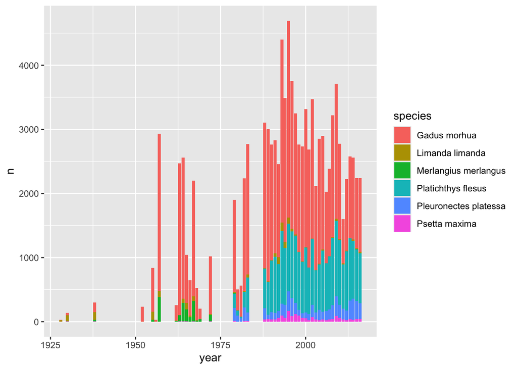

```r
t <- DataStuart |> filter(CPUEst == 0)


DataStuart |>
  drop_na(year) |>
  filter(!CPUEst == 0) |>
  summarise(n = n(), .by = c(year, species)) |>
  ggplot(aes(year, n, fill = species)) +
  geom_bar(stat = "identity")
```

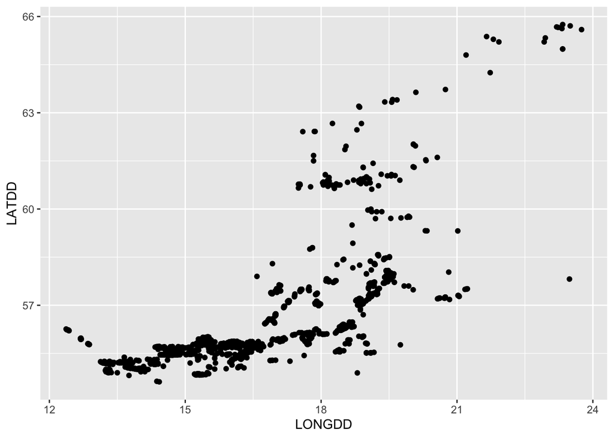

```r
DataStuart |>
  drop_na(year) |>
  distinct(IDX, .keep_all = TRUE) |>
  ggplot(aes(LONGDD, LATDD)) +
  geom_point()
```

```r
DataStuart_ids <- unique(DataStuart$IDX)

DataStuart <- DataStuart |>
  separate(IDX, sep = ":", into = c("IDX_SSB", "date2"), remove = FALSE) |>
  dplyr::select(-date2)

# unique(is.na(DataStuart$IDX))
#
# t <- DataStuart |> filter(is.na(IDX))
#
# unique(is.na(t))
#
# t2 <- t |>
#   filter(CPUEun)
```

## DATRAS

```r
######### standardization DATRAS

### Read the zip file

datras <- readExchange(paste0(home, "/data/trawl-data-historical/Datras/Exchange Data_2017-03-28 11_54_40.zip"))
```

[output not shown]

[output cut: 25 more lines]

[output not shown]

```r
####### HH

HH <- datras[["HH"]]

names(HH)
```

```
 [1] "RecordType"        "Survey"            "Quarter"
 [4] "Country"           "Ship"              "Gear"
 [7] "SweepLngt"         "GearExp"           "DoorType"
[10] "StNo"              "HaulNo"            "Year"
[13] "Month"             "Day"               "TimeShot"
[16] "Stratum"           "HaulDur"           "DayNight"
[19] "ShootLat"          "ShootLong"         "HaulLat"
[22] "HaulLong"          "StatRec"           "Depth"
[25] "HaulVal"           "HydroStNo"         "StdSpecRecCode"
[28] "BycSpecRecCode"    "DataType"          "Netopening"
[31] "Rigging"           "Tickler"           "Distance"
[34] "Warplngt"          "Warpdia"           "WarpDen"
[37] "DoorSurface"       "DoorWgt"           "DoorSpread"
[40] "WingSpread"        "Buoyancy"          "KiteDim"
[43] "WgtGroundRope"     "TowDir"            "GroundSpeed"
[46] "SpeedWater"        "SurCurDir"         "SurCurSpeed"
[49] "BotCurDir"         "BotCurSpeed"       "WindDir"
[52] "WindSpeed"         "SwellDir"          "SwellHeight"
[55] "SurTemp"           "BotTemp"           "SurSal"
[58] "BotSal"            "ThermoCline"       "ThClineDepth"
[61] "DateofCalculation" "haul.id"           "abstime"
[64] "timeOfYear"        "TimeShotHour"      "lon"
[67] "lat"               "Roundfish"
```

```r
# levels(HH$haul.id)

### put year as numeric

HH$Year <- as.numeric(as.character(HH$Year))

HH <- HH |> filter(Year <= 2016)

###### select just valid, additional and no oxygen hauls from every country except Sweden

HHdata <- HH |>
  filter(Country != "SWE" & HaulVal %in% c("A", "N", "V"))


####### fix SD and ICES rect
pts <- SpatialPoints(cbind(HHdata$lon, HHdata$lat),
  proj4string = CRS(proj4string(xx))
)

HHdata$SD <- over(pts, xx)$Area_27

HHdata <- HHdata |>
  mutate(
    SD = factor(SD),
    SD = fct_recode(SD,
      "20" = "3.a.20",
      "21" = "3.a.21",
      "22" = "3.c.22",
      "23" = "3.b.23",
      "24" = "3.d.24",
      "25" = "3.d.25",
      "26" = "3.d.26",
      "27" = "3.d.27",
      "28" = "3.d.28.1",
      "28" = "3.d.28.2",
      "29" = "3.d.29"
    )
  )
HHdata$Rect <- mapplots::ices.rect2(HHdata$lon, HHdata$lat)

# summary(HHdata$Rect)
# summary(factor(HHdata$StatRec))

##### there are 7 hauls with no depth registered. I will just put an aprox depth for one haul in SD 24, for one in 26 and 4 in SD 22.

HHdata[is.na(HHdata$Depth), ]
```

```
      RecordType Survey Quarter Country Ship Gear SweepLngt GearExp DoorType
3869          HH   BITS       4     DEN DAN2  TVL        75       S       NA
3918          HH   BITS       4     DEN  HAF  TVS        60    <NA>       NA
4701          HH   BITS       4     DEN  HAF  TVS        60    <NA>       NA
4857          HH   BITS       1     DEN  HAF  TVS        NA       S       NA
7629          HH   BITS       4     DEN  HAF  TVS        NA       S       NA
8004          HH   BITS       4     DEN  HAF  TVS        NA       S       NA
8129          HH   BITS       4     DEN  HAF  TVS        NA       S       NA
10591         HH   BITS       4     DEN DAN2  TVL        NA       S     TRUE
        StNo HaulNo Year Month Day TimeShot Stratum HaulDur DayNight ShootLat
3869      18      9 2000    11  14     1049      NA      30        D  54.6397
3918  018138      1 2000    10  17      730      NA      30        D  56.1000
4701    8882     25 2002    10  25      715      NA      30        D  55.5333
4857    8958      9 2003     3   9     1505      NA      30        D  57.1627
7629    1878     27 2008    10  15      555      NA      30        D  55.4408
```

[output cut: 75 more lines]

```r
HHdata$Depth[is.na(HHdata$Depth) & HHdata$SD == "26"] <- 115
HHdata$Depth[is.na(HHdata$Depth) & HHdata$SD == "24"] <- 31
HHdata$Depth[is.na(HHdata$Depth) & HHdata$SD == "22" & HHdata$haul.id == "2000:4:DEN:HAF:TVS:018138:1"] <- 23
HHdata$Depth[is.na(HHdata$Depth) & HHdata$SD == "22" & HHdata$haul.id == "2002:4:DEN:HAF:TVS:8882:25"] <- 37
HHdata$Depth[is.na(HHdata$Depth) & HHdata$SD == "22" & HHdata$haul.id == "2008:4:DEN:HAF:TVS:1878:27"] <- 15
HHdata$Depth[is.na(HHdata$Depth) & HHdata$SD == "22" & HHdata$haul.id == "2009:4:DEN:HAF:TVS:2365:28"] <- 20




####### HL

HL <- datras[["HL"]]

HL |>
  summarise(n = n(), .by = Species) |>
  arrange(desc(n))
```

```
                         Species      n
1                   Gadus morhua 289535
2                Clupea harengus 215284
3             Platichthys flesus 151780
4              Sprattus sprattus  95752
5          Pleuronectes platessa  62481
6           Merlangius merlangus  56146
7                Limanda limanda  46302
8         Myoxocephalus scorpius  13046
9           Enchelyopus cimbrius  11866
10  Hippoglossoides platessoides   9820
11                          <NA>   7419
12           Trachurus trachurus   7087
13                 Psetta maxima   6484
14             Osmerus eperlanus   5421
```

[output cut: 137 more lines]

```r
names(HL)
```

```
 [1] "haul.id"           "RecordType"        "Survey"
 [4] "Quarter"           "Country"           "Ship"
 [7] "Gear"              "SweepLngt"         "GearExp"
[10] "DoorType"          "StNo"              "HaulNo"
[13] "Year"              "SpecCodeType"      "SpecCode"
[16] "SpecVal"           "Sex"               "TotalNo"
[19] "CatIdentifier"     "NoMeas"            "SubFactor"
[22] "SubWgt"            "CatCatchWgt"       "LngtCode"
[25] "LngtClas"          "HLNoAtLngt"        "DateofCalculation"
[28] "Valid_Aphia"       "LngtCm"            "Species"
[31] "HaulDur"           "DataType"          "Count"
```

```r
### put year as numeric

HL$Year <- as.numeric(as.character(HL$Year))

HL <- HL |> filter(Year <= 2016)

###### select just the hauls in HHdata

HLdata <- HL[HL$haul.id %in% HHdata$haul.id, ]

# write.csv(HLdata,"Datras/HLdata.csv")

#### match haul SD, rect, haul validity, StdSpecRecCode and BycSpecRecCode

HLdata$SD <- HHdata[match(HLdata$haul.id, HHdata$haul.id), "SD"]
HLdata$Rect <- HHdata[match(HLdata$haul.id, HHdata$haul.id), "Rect"]
HLdata$HaulVal <- HHdata[match(HLdata$haul.id, HHdata$haul.id), "HaulVal"]
HLdata$StdSpecRecCode <- HHdata[match(HLdata$haul.id, HHdata$haul.id), "StdSpecRecCode"]
HLdata$BycSpecRecCode <- HHdata[match(HLdata$haul.id, HHdata$haul.id), "BycSpecRecCode"]


# summary(HLdata$HaulVal)
# summary(HHdata$HaulVal)

####### select different species

hlcod <- HLdata |>
  filter(Species == "Gadus morhua")

hlflo <- HLdata |>
  filter(Species == "Platichthys flesus")

hlpla <- HLdata |>
  filter(Species == "Pleuronectes platessa")

hldab <- HLdata |>
  filter(Species == "Limanda limanda")

hltur <- HLdata |>
  filter(Species == "Psetta maxima")

hlwhi <- HLdata |>
  filter(Species == "Merlangius merlangus")

##### add 0 catches
#### common columns for merging
comcol <- intersect(names(hlcod), names(HHdata))
comcol <- comcol[-c(2, 14, 16)]

##### for cod add 0s and then remove lines with SpecVal = 0
hlcod0 <- merge(hlcod, HHdata[, comcol], by = comcol, all = TRUE)
# summary(hlcod0)

hlcod0$SpecVal[is.na(hlcod0$SpecVal)] <- "zeroCatch"
hlcod0$SpecVal <- factor(hlcod0$SpecVal)

hlcod0 <- hlcod0 |>
  filter(SpecVal != "0")

hlcod0$Species <- "Gadus morhua"



##### for flounder add 0s, remove them if StdSpecRecCode !=1 and then remove lines with SpecVal = 0
hlflo0 <- merge(hlflo, HHdata[, comcol], by = comcol, all = TRUE)
# summary(hlflo0)

hlflo0 <- hlflo0[!(is.na(hlflo0$Species) & hlflo0$StdSpecRecCode != 1), ]

hlflo0$SpecVal[is.na(hlflo0$SpecVal)] <- "zeroCatch"
hlflo0$SpecVal <- factor(hlflo0$SpecVal)

hlflo0 <- hlflo0 |>
  filter(SpecVal != "0")

hlflo0$Species <- "Platichthys flesus"

##### for plaice add 0s, remove them if StdSpecRecCode !=1 and then remove lines with SpecVal = 0
hlpla0 <- merge(hlpla, HHdata[, comcol], by = comcol, all = TRUE)
# summary(hlpla0)

hlpla0 <- hlpla0[!(is.na(hlpla0$Species) & hlpla0$StdSpecRecCode != 1), ]

hlpla0$SpecVal[is.na(hlpla0$SpecVal)] <- "zeroCatch"
hlpla0$SpecVal <- factor(hlpla0$SpecVal)

hlpla0 <- hlpla0 |>
  filter(SpecVal != "0")

hlpla0$Species <- "Pleuronectes platessa"

##### for dab add 0s, remove them if BycSpecRecCode !=1 and then remove lines with SpecVal = 0
hldab0 <- merge(hldab, HHdata[, comcol], by = comcol, all = TRUE)
# summary(hldab0)

hldab0 <- hldab0[!(is.na(hldab0$Species) & hldab0$BycSpecRecCode != 1), ]

hldab0$SpecVal[is.na(hldab0$SpecVal)] <- "zeroCatch"
hldab0$SpecVal <- factor(hldab0$SpecVal)

hldab0 <- hldab0 |>
  filter(SpecVal != "0")

hldab0$Species <- "Limanda limanda"

##### for turbot add 0s, remove them if BycSpecRecCode !=1 and then remove lines with SpecVal = 0
hltur0 <- merge(hltur, HHdata[, comcol], by = comcol, all = TRUE)
# summary(hltur0)

hltur0 <- hltur0[!(is.na(hltur0$Species) & hltur0$BycSpecRecCode != 1), ]

hltur0$SpecVal[is.na(hltur0$SpecVal)] <- "zeroCatch"
hltur0$SpecVal <- factor(hltur0$SpecVal)

hltur0 <- hltur0 |>
  filter(SpecVal != "0")

hltur0$Species <- "Psetta maxima"

##### for whiting add 0s, remove them if BycSpecRecCode !=1 and then remove lines with SpecVal = 0
hlwhi0 <- merge(hlwhi, HHdata[, comcol], by = comcol, all = TRUE)
# summary(hlwhi0)

hlwhi0 <- hlwhi0[!(is.na(hlwhi0$Species) & hlwhi0$BycSpecRecCode != 1), ]

hlwhi0$SpecVal[is.na(hlwhi0$SpecVal)] <- "zeroCatch"
hlwhi0$SpecVal <- factor(hlwhi0$SpecVal)

hlwhi0 <- hlwhi0 |>
  filter(SpecVal != "0")

hlwhi0$Species <- "Merlangius merlangus"


#### check number of hauls for each species
n_distinct(HHdata$haul.id)
```

```
[1] 11504
```

```r
n_distinct(hlcod0$haul.id)
```

```
[1] 11492
```

```r
n_distinct(hlflo0$haul.id)
```

```
[1] 11156
```

```r
n_distinct(hlpla0$haul.id)
```

```
[1] 10661
```

```r
n_distinct(hldab0$haul.id)
```

```
[1] 10179
```

```r
n_distinct(hltur0$haul.id)
```

```
[1] 10173
```

```r
n_distinct(hlwhi0$haul.id)
```

```
[1] 10178
```

```r
####### create CPUE unstandardized for SpecVal=1. If DataType = C then CPUEun=HLNoAtLngt, if DataType=R then CPUEun=HLNoAtLngt/(HaulDur/60), if DataType = S then CPUEun=(HLNoAtLngt*SubFactor)/(HaulDur/60). If SpecVal="zeroCatch" then CPUEun=0, if SpecVal=4 we need to decide.
# Then I will sum for the same haul the CPUE of the same length classes if they were sampled with different subfactors or with different sexes.

#### cod
hlcod0 <- hlcod0 |>
  mutate(CPUEun = ifelse(SpecVal == "1" & DataType == "C", HLNoAtLngt, ifelse(SpecVal == "1" & DataType == "R", HLNoAtLngt / (HaulDur / 60), ifelse(SpecVal == "1" & DataType == "S", (HLNoAtLngt * SubFactor) / (HaulDur / 60), ifelse(SpecVal == "zeroCatch", 0, NA)))))

##### create the data.frame with records without LFD

hlcod4 <- hlcod0 |>
  filter(SpecVal == "4")

#### sum the CPUE for the fishes of the same length class in a haul
colsumsex <- names(hlcod0)[c(1:22, 30, 31, 35:37, 39)]


hlcodL <- hlcod0[, colsumsex] |>
  filter(!SpecVal == "4")

temp <- summaryBy(CPUEun ~ LngtClas + haul.id, data = hlcodL, FUN = sum, keep.names = TRUE)

hlcodL <- merge(hlcodL[, -28], temp, by = c("LngtClas", "haul.id"), all.y = TRUE)

hlcodL <- unique(hlcodL)

#### flounder
hlflo0 <- hlflo0 |>
  mutate(CPUEun = ifelse(SpecVal == "1" & DataType == "C", HLNoAtLngt, ifelse(SpecVal == "1" & DataType == "R", HLNoAtLngt / (HaulDur / 60), ifelse(SpecVal == "1" & DataType == "S", (HLNoAtLngt * SubFactor) / (HaulDur / 60), ifelse(SpecVal == "zeroCatch", 0, NA)))))

##### create the data.frame with records without LFD

hlflo4 <- hlflo0 |>
  filter(SpecVal == "4")

#### sum the CPUE for the fishes of the same length class in a haul

hlfloL <- hlflo0[, colsumsex] |>
  filter(!SpecVal == "4")

temp <- summaryBy(CPUEun ~ LngtClas + haul.id, data = hlfloL, FUN = sum, keep.names = TRUE)

hlfloL <- merge(hlfloL[, -28], temp, by = c("LngtClas", "haul.id"), all.y = TRUE)

hlfloL <- unique(hlfloL)

#### plaice
hlpla0 <- hlpla0 |>
  mutate(CPUEun = ifelse(SpecVal == "1" & DataType == "C", HLNoAtLngt, ifelse(SpecVal == "1" & DataType == "R", HLNoAtLngt / (HaulDur / 60), ifelse(SpecVal == "1" & DataType == "S", (HLNoAtLngt * SubFactor) / (HaulDur / 60), ifelse(SpecVal == "zeroCatch", 0, NA)))))

##### create the data.frame with records without LFD

hlpla4 <- hlpla0 |>
  filter(SpecVal == "4")

#### sum the CPUE for the fishes of the same length class in a haul

hlplaL <- hlpla0[, colsumsex] |>
  filter(!SpecVal == "4")

temp <- summaryBy(CPUEun ~ LngtClas + haul.id, data = hlplaL, FUN = sum, keep.names = TRUE)

hlplaL <- merge(hlplaL[, -28], temp, by = c("LngtClas", "haul.id"), all.y = TRUE)

hlplaL <- unique(hlplaL)


#### dab
hldab0 <- hldab0 |>
  mutate(CPUEun = ifelse(SpecVal == "1" & DataType == "C", HLNoAtLngt, ifelse(SpecVal == "1" & DataType == "R", HLNoAtLngt / (HaulDur / 60), ifelse(SpecVal == "1" & DataType == "S", (HLNoAtLngt * SubFactor) / (HaulDur / 60), ifelse(SpecVal == "zeroCatch", 0, NA)))))

##### create the data.frame with records without LFD

hldab4 <- hldab0 |>
  filter(SpecVal == "4")

#### sum the CPUE for the fishes of the same length class in a haul

hldabL <- hldab0[, colsumsex] |>
  filter(!SpecVal == "4")

temp <- summaryBy(CPUEun ~ LngtClas + haul.id, data = hlplaL, FUN = sum, keep.names = TRUE)

hldabL <- merge(hldabL[, -28], temp, by = c("LngtClas", "haul.id"), all.y = TRUE)

hldabL <- unique(hldabL)


#### turbot
hltur0 <- hltur0 |>
  mutate(CPUEun = ifelse(SpecVal == "1" & DataType == "C", HLNoAtLngt, ifelse(SpecVal == "1" & DataType == "R", HLNoAtLngt / (HaulDur / 60), ifelse(SpecVal == "1" & DataType == "S", (HLNoAtLngt * SubFactor) / (HaulDur / 60), ifelse(SpecVal == "zeroCatch", 0, NA)))))

##### create the data.frame with records without LFD

hltur4 <- hltur0 |>
  filter(SpecVal == "4")

#### sum the CPUE for the fishes of the same length class in a haul

hlturL <- hltur0[, colsumsex] |>
  filter(!SpecVal == "4")

temp <- summaryBy(CPUEun ~ LngtClas + haul.id, data = hlplaL, FUN = sum, keep.names = TRUE)

hlturL <- merge(hlturL[, -28], temp, by = c("LngtClas", "haul.id"), all.y = TRUE)

hlturL <- unique(hlturL)



#### whiting
hlwhi0 <- hlwhi0 |>
  mutate(CPUEun = ifelse(SpecVal == "1" & DataType == "C", HLNoAtLngt, ifelse(SpecVal == "1" & DataType == "R", HLNoAtLngt / (HaulDur / 60), ifelse(SpecVal == "1" & DataType == "S", (HLNoAtLngt * SubFactor) / (HaulDur / 60), ifelse(SpecVal == "zeroCatch", 0, NA)))))

##### create the data.frame with records without LFD

hlwhi4 <- hlwhi0 |>
  filter(SpecVal == "4")

#### sum the CPUE for the fishes of the same length class in a haul

hlwhiL <- hlwhi0[, colsumsex] |>
  filter(!SpecVal == "4")

temp <- summaryBy(CPUEun ~ LngtClas + haul.id, data = hlplaL, FUN = sum, keep.names = TRUE)

hlwhiL <- merge(hlwhiL[, -28], temp, by = c("LngtClas", "haul.id"), all.y = TRUE)

hlwhiL <- unique(hlwhiL)



######### CA

CA <- datras[["CA"]]

CA <- CA %>% map_df(., rep, .$NoAtALK)

### put year as numeric

CA$Year <- as.numeric(as.character(CA$Year))

CA <- CA |> filter(Year <= 2016)

###### select just the hauls in HHdata

CAdata <- CA[CA$haul.id %in% HHdata$haul.id, ]



#### match haul SD, rect, haul validity

CAdata$SD <- HHdata[match(CAdata$haul.id, HHdata$haul.id), "SD"]
CAdata$Rect <- HHdata[match(CAdata$haul.id, HHdata$haul.id), "Rect"]
CAdata$HaulVal <- HHdata[match(CAdata$haul.id, HHdata$haul.id), "HaulVal"]

####### select different species remove missing individual weights or weight = 0
cacod <- CAdata |>
  filter(Species == "Gadus morhua" & IndWgt != 0 & !(is.na(IndWgt)))

caflo <- CAdata |>
  filter(Species == "Platichthys flesus" & IndWgt != 0 & !(is.na(IndWgt)))

capla <- CAdata |>
  filter(Species == "Pleuronectes platessa" & IndWgt != 0 & !(is.na(IndWgt)))

cadab <- CAdata |>
  filter(Species == "Limanda limanda" & IndWgt != 0 & !(is.na(IndWgt)))

catur <- CAdata |>
  filter(Species == "Psetta maxima" & IndWgt != 0 & !(is.na(IndWgt)))

cawhi <- CAdata |>
  filter(Species == "Merlangius merlangus" & IndWgt != 0 & !(is.na(IndWgt)))
```